# HoloViews 1.13 Release

### Panel based widgets

HoloViews has shipped with a set of widgets to explore multi-dimensional parameter spaces since its first public release. These widgets were written as a weekend project and did not follow many of the best practices of Javascript development. This meant they were hard to extend, exhibit a variety of issues related to character encoding and were not at all customizable. In HoloViews 1.13.0 we completely replaced most of the rendering machinery and widget code with [Panel](https://panel.holoviz.org) widgets making them easier to maintain, customize and extend.

Specifically so far the widgets have always been located at the right of a plot, but now we have full flexibility to override this:

```python
calcium_hmap = hv.HoloMap({i: hv.Image(calcium_array[:, :, i]) for i in range(10)}, 'Time')

hv.output(calcium_hmap, widget_location='bottom')
```

[interactive chart not shown]

### Spatialpandas and polygon datashading

HoloViews has long had strong support for both gridded and tabular data, with geometry data support being more spotty. In HoloViews 1.13.0 the core model around support for geometry data was redesigned from the ground up, in particular HoloViews can now convert natively between different geometry storage backends including the native dictionary format, geopandas (if GeoViews is installed) and the new addition called spatialpandas. [Spatialpandas](https://github.com/holoviz/spatialpandas) is closely modeled on GeoPandas but does not have the same heavy GIS dependencies and is highly optimized, efficiently make use of pandas extension arrays. All of this means that spatialpandas is significantly more performant than geopandas and can also be directly ingested into datashader, making it possible to render thousands or even millions of geometries, including polygons, very quickly.

```python
nyc_buildings = hv.Polygons(buildings, ['x', 'y'], 'type')

datashade(nyc_buildings, aggregator=ds.by('type', ds.count()), color_key=glasbey);
```

[figure not shown]

In addition to `Polygons` this release also brings support for datashading a range of other plot types including `Area`, `Spikes` and `Segments`:

```python
xs, ys, O, H, L, C = OHLC(1000000)

area = hv.Area((xs, O))

segments = hv.Segments((xs, L, xs, H))

(datashade(area, aggregator='any') + datashade(segments) + datashade(hv.Spikes(O))).opts(shared_axes=False)
```

[interactive chart not shown]

### Improved Plotly support

The Plotly backend has long been only partially supported with a wide swath of element types not being implemented. This release brought feature parity between bokeh and plotly backends much closer by implementing a wide range of plot types including:

- `Bars`
- `Bounds`
- `Box`
- `Ellipse`
- `HLine`/`VLine`
- `HSpan`/`VSpan`
- `Histogram`
- `RGB`

Below we can see examples of each of the element types:

```python
(bars + hist + path + rgb + hspan + shapes).opts(shared_axes=False).cols(2)
```

[interactive chart not shown]

Additionally the Plotly backend now supports interactivity with support linked streams allowing for deep interactivity, e.g. linked brushing is also supported:

[figure not shown]

### GIF support for Bokeh and Plotly

It has long been possible to generate GIFs with HoloViews using the Matplotlib backend. In this release however we have finally extended that support to both the Bokeh and Plotly backends, e.g. here we create a GIF zooming in on the Empire State building in the building dataset:

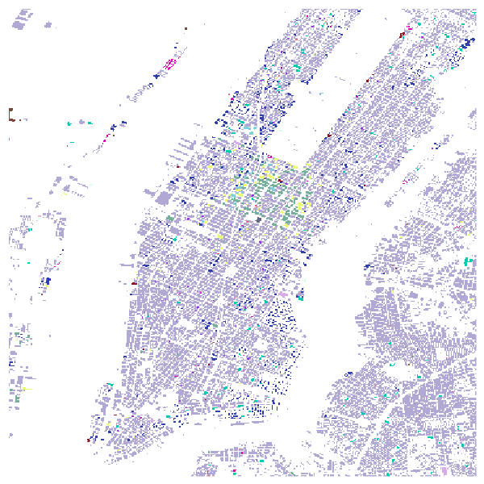

```python
empire_state_loc = -73.9857, 40.7484

def nyc_zoom(zoom):
    x, y = empire_state_loc
    width = (0.05-0.005*zoom)
    return datashade(nyc_buildings, aggregator=ds.by('type', ds.any()), color_key=glasbey[::-1],
                     x_range=(x-width, x+width), y_range=(y-width, y+width), dynamic=False, min_alpha=0)

hmap = hv.HoloMap({i: nyc_zoom(i) for i in range(10)}).opts(
    xaxis=None, yaxis=None, title='', toolbar=None, framewise=True,
    width=600, height=600, show_frame=False, backend='bokeh'
)

hv.output(hmap, holomap='gif', backend='bokeh', fps=2)
```

### What’s next?

In the coming months we will finally be focusing on a HoloViews 2.0 release where the main aims are:

- Splitting plotting and data components into separate packages
- API cleanup
- More consistent styling between backends

Additionally we are continuing to work on some exciting features:

- Further work on the Plotly backend making it a more equal citizen in the HoloViz ecosystem
- Additions of new data interfaces including Vaex and Ibis
- Better support for Pandas multi-indexes

Back to top